# 2019 vs 2020 CitiBike

AnaPatricia Olvera

7/23/2020

The purpose of this is to compare 2019 vs 2020 data from the CitiBike in NYC.

```r
marchJune19 <- rbind(read.csv("citibikeData/RealData/201903-citibike-tripdata.csv"),
                     read.csv("citibikeData/RealData/201904-citibike-tripdata.csv"),
                     read.csv("citibikeData/RealData/201905-citibike-tripdata.csv"),
                     read.csv("citibikeData/RealData/201906-citibike-tripdata.csv"))
```

```r
marchJune20 <- rbind(read.csv("citibikeData/202003-citibike-tripdata.csv"),
                     read.csv("citibikeData/202004-citibike-tripdata.csv"),
                     read.csv("citibikeData/202005-citibike-tripdata.csv"),
                     read.csv("citibikeData/202006-citibike-tripdata.csv"))
```

First, let’s clean both data sets

```r
marchJune19 <- marchJune19%>%na.omit()
marchJune19 <- marchJune19%>%filter( tripduration >=0 & tripduration <= 1800)
marchJune19 <- marchJune19%>%filter( (2019 - birth.year ) <= 70)
```

```r
marchJune20 <- marchJune20%>%na.omit()
marchJune20 <- marchJune20%>%filter( tripduration >=0 & tripduration <= 1800)
marchJune20 <- marchJune20%>%filter( (2019 - birth.year ) <= 70)
```

Now let’s create a weekday column

```r
marchJune19 <- marchJune19%>%separate(starttime, c("start.date", "start.time"), " ")
marchJune19 <- marchJune19%>%separate(stoptime, c("stop.date", "stop.time"), " ")
marchJune19$weekday <- weekdays(as.Date(marchJune19$start.date))
```

```r
marchJune20 <- marchJune20%>%separate(starttime, c("start.date", "start.time"), " ")
marchJune20 <- marchJune20%>%separate(stoptime, c("stop.date", "stop.time"), " ")
marchJune20$weekday <- weekdays(as.Date(marchJune20$start.date))
```

```r
g <- function(y){
  if( y == 1){
    return("Male")
  }
  if( y== 2){
    return("Female")
  }
  if(y==0){
    return("Unknown")
  }
}
```

```r
marchJune19$gender<- sapply(marchJune19$gender, g)
marchJune20$gender<- sapply(marchJune20$gender, g)
```

Average trip duration: 2019:

```r
mean( marchJune19$tripduration, trim = 0, na.rm = T) / 60
```

```
## [1] 11.3472
```

2020:

```r
mean( marchJune20$tripduration, trim = 0, na.rm = T) / 60
```

```
## [1] 13.57526
```

Most popular start stations in 2019:

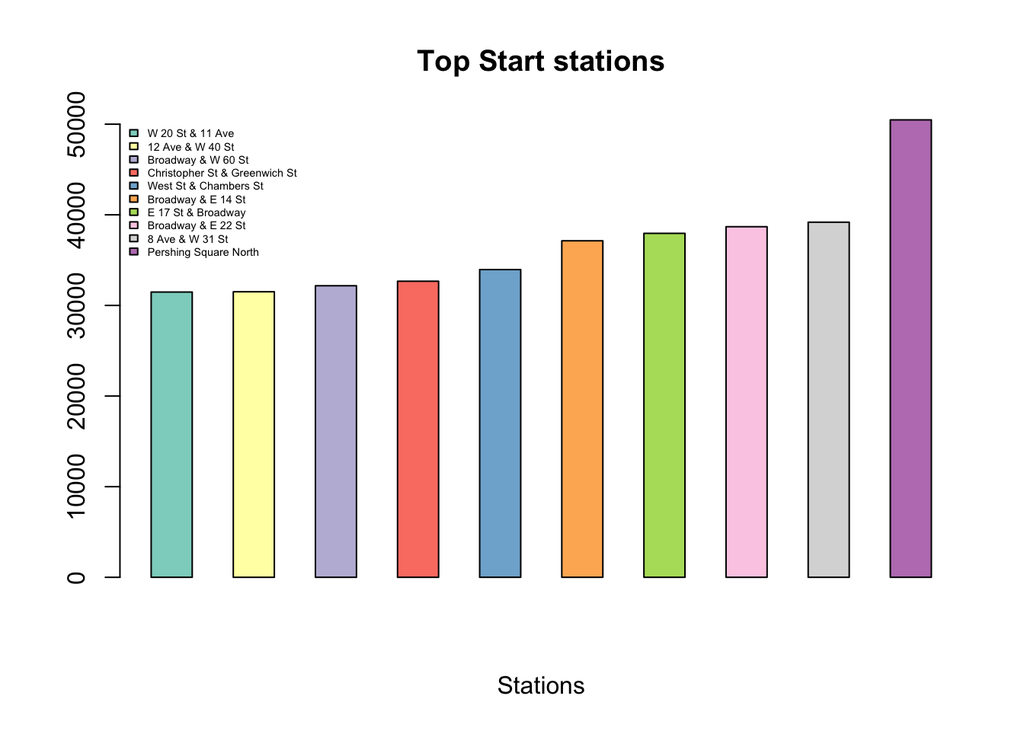

```r
colBar3 <- brewer.pal(10, "Set3")
with(diamonds, barplot(rev(sort(table(marchJune19$start.station.name), decreasing = T )[1:10]), width = 10, main= "Top Start stations", space= 1, xlab = "Stations", legend.text = T, col= colBar3, names.arg = F, args.legend= list(x = "topleft", bty = "n", cex= 0.45)))
```

Perishing Square Noth was the top 1 station, reporting a bit more than 50,000 trips starting from this point.

Most popular start stations in 2020:

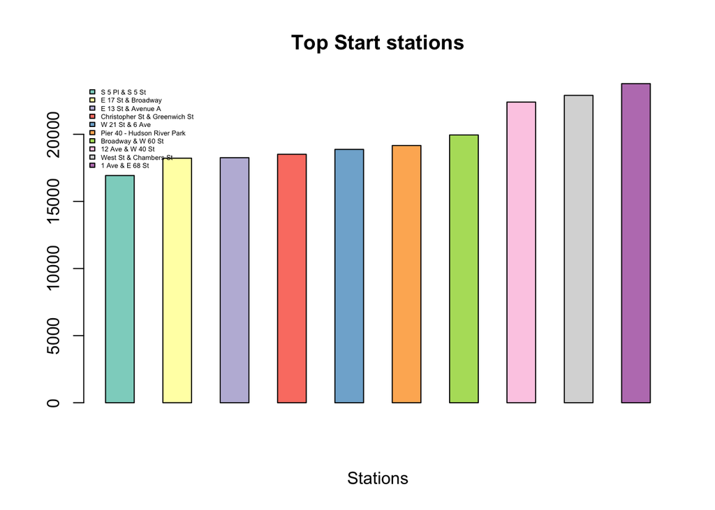

```r
with(diamonds, barplot(rev(sort(table(marchJune20$start.station.name), decreasing = T )[1:10]), width = 10, main= "Top Start stations", space= 1, xlab = "Stations", legend.text = T, col= colBar3, names.arg = F, args.legend= list(x = "topleft", bty = "n", cex= 0.40)))
```

1Ave & E 68St is the top one start station repoting a bit more than 20,000 trips starting there.

Most popular end station in 2019:

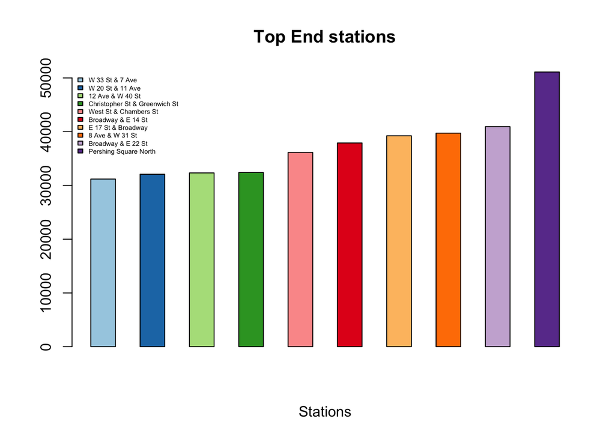

```r
colBar2 <- brewer.pal(10, "Paired")
with(diamonds, barplot(rev(sort(table(marchJune19$end.station.name), decreasing = T)[1:10]), width = 10,  main= "Top End stations", space= 1, xlab = "Stations", legend.text = T, col= colBar2, names.arg = F, args.legend= list(x = "topleft", bty = "n", cex= 0.45)))
```

Pershing Square North is the most popular end station, with about 50,000 trips ended here. Most popular end station 2020:

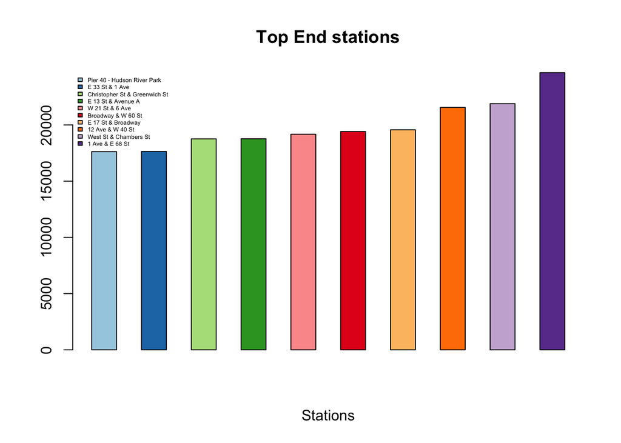

```r
with(diamonds, barplot(rev(sort(table(marchJune20$end.station.name), decreasing = T)[1:10]), width = 10,  main= "Top End stations", space= 1, xlab = "Stations", legend.text = T, col= colBar2, names.arg = F, args.legend= list(x = "topleft", bty = "n", cex= 0.40)))
```

Again, 1 Ave & E 68St is the most popular end station.

Busiest day of the week in 2019:

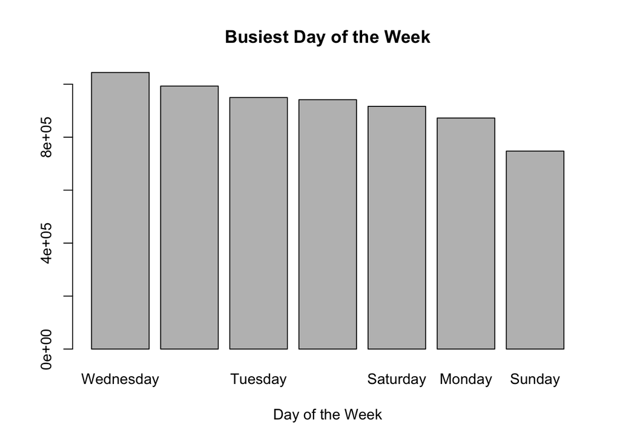

```r
with(diamonds, barplot(rev(sort(table(marchJune19$weekday) )[1:7]), width = 10, main= "Busiest Day of the Week", xlab= "Day of the Week"))
```

The busiest day of the week in 2019 was Wednesday. Busiest day of the week in 2020:

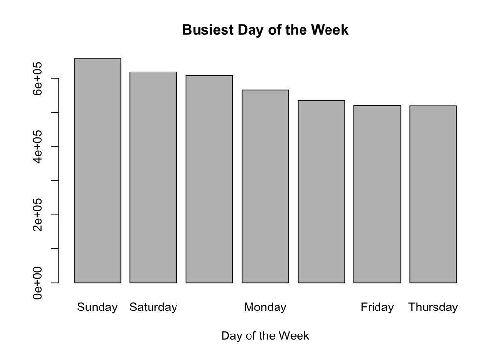

```r
with(diamonds, barplot(rev(sort(table(marchJune20$weekday) )[1:7]), width = 10, main= "Busiest Day of the Week", xlab= "Day of the Week"))
```

The busiest day of the week in 2020 is Sunday.

Who biked more in the busiest day in 2019?

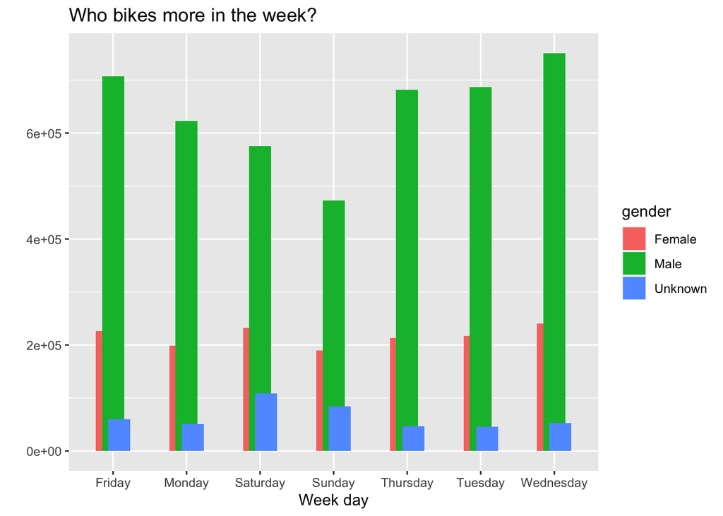

```r
ggplot(marchJune19, aes(x= weekday, fill= gender)) + geom_bar( stat = "count" , na.rm= T,
                                                              position = position_dodge(width = 0.25)) +
  labs(title= "Who bikes more in the week?", x= "Week day", y= "")
```

Males biked more. Who biked more in the busiest day in 2020?

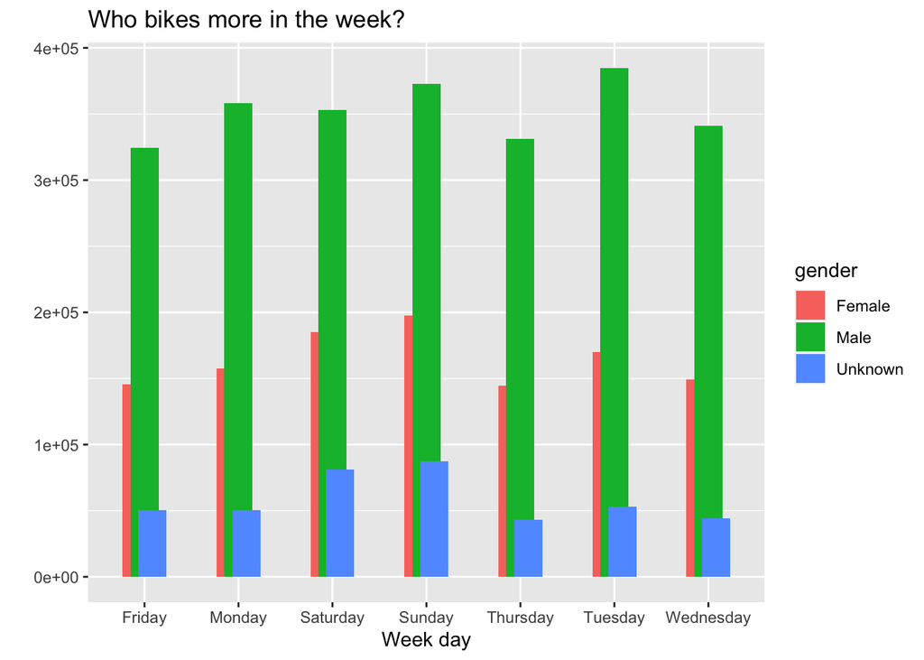

```r
ggplot(marchJune20, aes(x= weekday, fill= gender)) + geom_bar( stat = "count" , na.rm= T,
                                                              position = position_dodge(width = 0.25)) +
  labs(title= "Who bikes more in the week?", x= "Week day", y= "")
```

Again, males biked more.

let’s compare month by month the change

the Start Date is divided by year, month, and day

```r
marchJune19 <- marchJune19%>% separate(start.date, c("year", "month", "day"), "-")
marchJune20 <- marchJune20%>% separate(start.date, c("year", "month", "day"), "-")
```

now we will separate the data into different data frames

```r
march19 <- filter(marchJune19, month == '03')
march20 <- filter(marchJune20, month == '03')

april19 <- filter(marchJune19, month == '04')
april20 <- filter(marchJune20, month == '04')

may19 <- filter(marchJune19, month == '05')
may20 <- filter(marchJune20, month == '05')

june19 <- filter(marchJune19, month == '06')
june20 <- filter(marchJune20, month == '06')
```

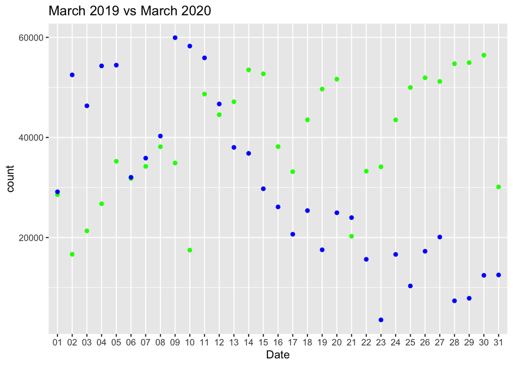

```r
ggplot() +
geom_point(data=march19 , aes(x=march19$day), color='green', stat = "count", na.rm= T) +
geom_point(data= march20, aes(x=march20$day), color='blue', stat = "count", na.rm= T) + labs( title = "March 2019 vs March 2020", x= "Date")
```

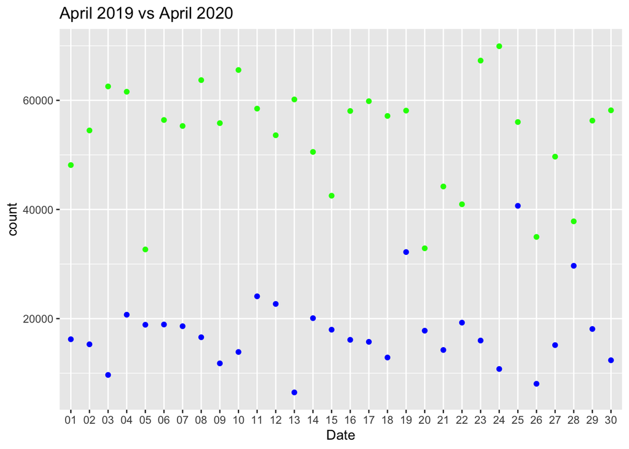

```r
ggplot()+
  geom_point(data = april19, aes(x=april19$day), color= 'green', stat = "count", na.rm = T)+
  geom_point(data = april20, aes(x=april20$day), color= 'blue', stat = "count", na.rm = T)+
  labs(title= "April 2019 vs April 2020", x= "Date")
```

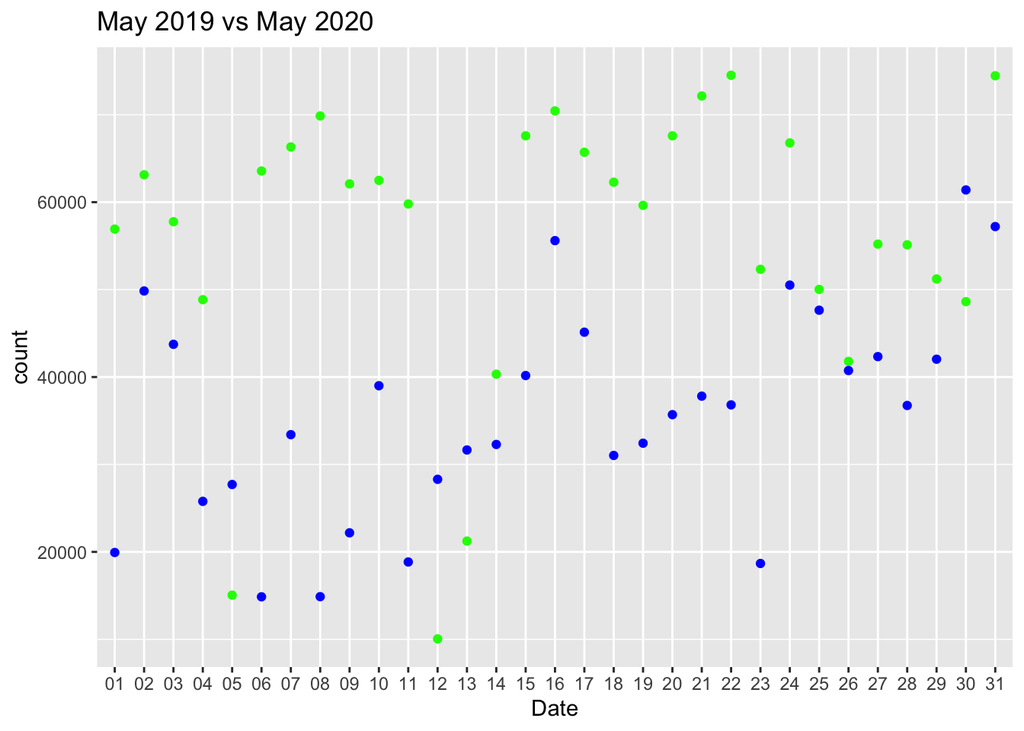

```r
ggplot()+
  geom_point(data = may19, aes(x=may19$day), color= 'green', stat = "count", na.rm = T)+
  geom_point(data = may20, aes(x=may20$day), color= 'blue', stat = "count", na.rm = T)+
  labs(title= "May 2019 vs May 2020", x= "Date")
```

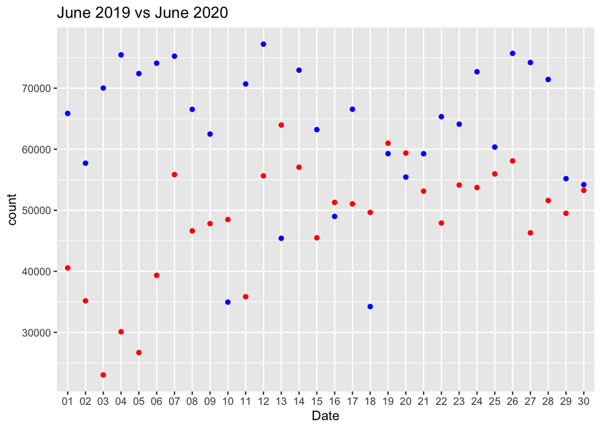

```r
ggplot()+
  geom_point(data = june19, aes(x=june19$day), color= 'blue', stat = "count", na.rm = T)+
  geom_line()+
  geom_point(data = june20, aes(x=june20$day), color= 'red', stat = "count", na.rm = T)+
  geom_line()+
  labs(title= "June 2019 vs June 2020", x= "Date")
```

trip duration 2019:

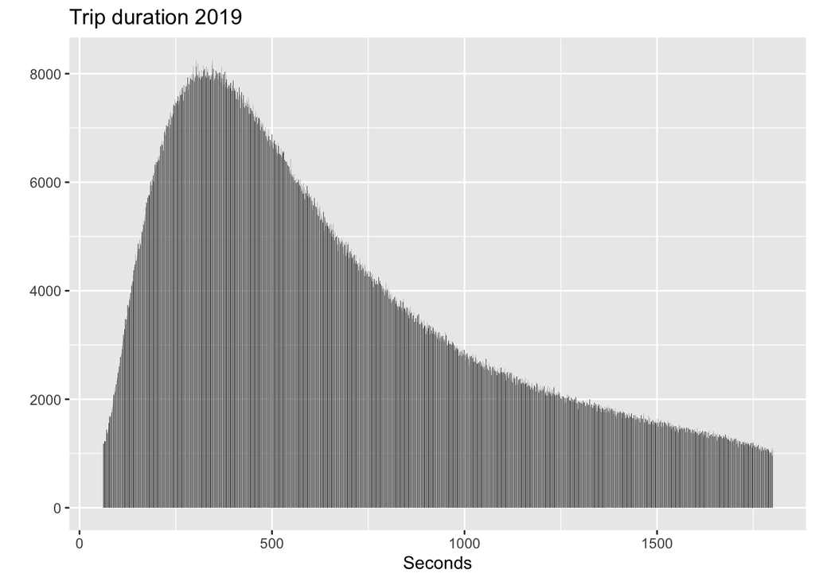

```r
ggplot(marchJune19) + geom_histogram(mapping = aes( x= marchJune19$tripduration), stat = "bin",
  position = "stack", binwidth = 0.5,
  na.rm = T
) + labs( title= "Trip duration 2019", x= "Seconds", y= "")
```

trip duration 2020:

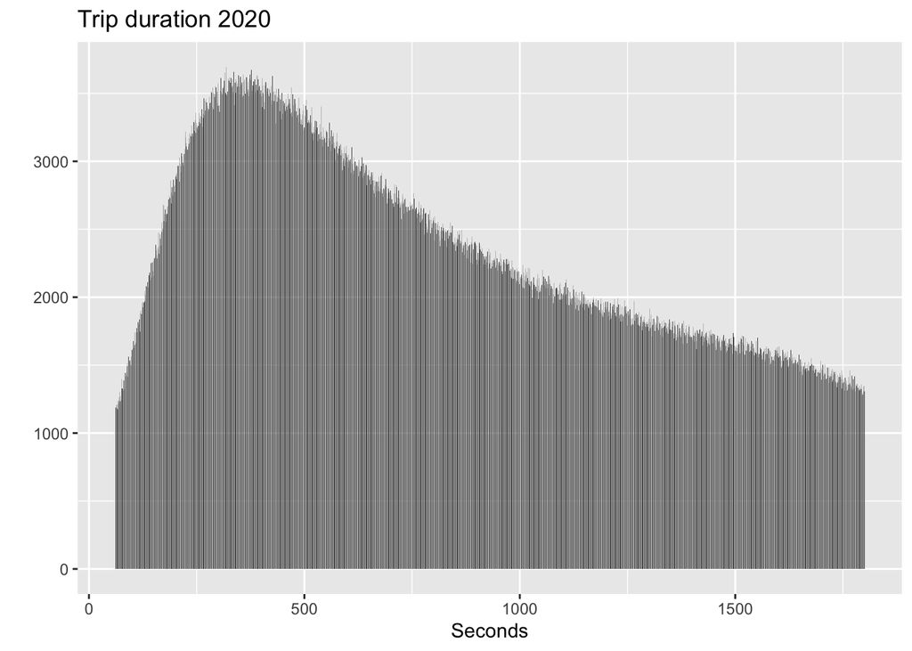

```r
ggplot(marchJune20) + geom_histogram(mapping = aes( x= marchJune20$tripduration), stat = "bin",
  position = "stack", binwidth = 0.5,
  na.rm = T
) + labs( title= "Trip duration 2020", x= "Seconds", y= "")
```

```r
#ggplot(marchJune19, aes(x= marchJune19$start.time, fill= 'green'))+ geom_bar(stat= "count", na.rm = T)+
 # scale_y_continuous("Number of trips", seq(0, 10000, by= 1000), limits= c(0,10000))+ labs(title= "Busiest hour", x= "Hour of the day")
```